# Predictive Modelling on CAD/AUD Foreign Exchange Rate

Bin Jiang

27 October 2016

## Overview of Modelling Process

This report shows in details how to build up a forecasting pipeline on CAD/AUD foreign exchange rate from scratch.

## CAD/AUD Exchange Rate Time series

```r
library(forecast)
setwd("/home/shenzhou/Dropbox/ANZ_SMALL_PROJECT")
cad_aud = read.csv("./data/audcad.csv", stringsAsFactors = FALSE)
df_forex = data.frame(cad_aud); colnames(df_forex) = c("date", "cadaud")
print(sum(colSums(is.na(cad_aud))))
```

```
## [1] 0
```

In our case, there are no missing values. If we do need to deal with missing values, one can actually use professional R packages to detect and impute them. Two packages I usually use jointly are

```r
library(mice)
library(VIM)
```

We store the CAD/AUD exchange rates as a R time-series object as below. This object type can largely facilitate time series analysis implemented by the R “Stats” package and “forecast” package.

```r
###### build up from naive univarate benchmarks: random walk, drift, mean model and seasonal naive #######
ts_forex = ts(as.numeric(cad_aud[,2]), frequency = 12, start = c(1991,1), end = c(2016,10))
```

The first thing to do in any data analysis task is to plot and summarise the data.

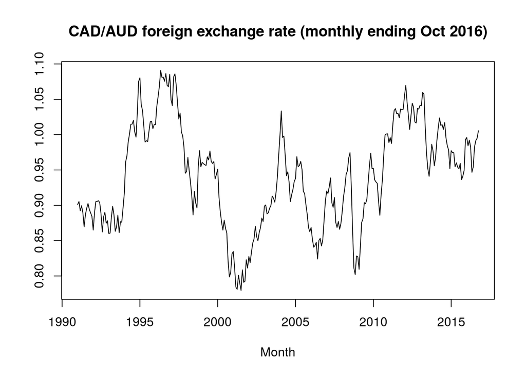

```r
plot(ts_forex, main="CAD/AUD foreign exchange rate (monthly ending Oct 2016)", ylab="",xlab="Month")
```

```r
summary(ts_forex)
```

```
##    Min. 1st Qu.  Median    Mean 3rd Qu.    Max.
##  0.7794  0.8865  0.9438  0.9406  0.9964  1.0910
```

The time plot immediately reveals some interesting features.

- The time series is clearly not stationary and we have to take this into account in predictive modelling.
- There is a clear economic cyclic pattern related to business cycle. Thus, fundamental economic indicators should contain forecasting power. Two key periods are the 2001 – 2003 of dot-com bubble crash and 2008 – 2010 of Subprime crisis. Moreover, these are also structural breaks which can be possibly modelled with econometric models.
- There is no obvious seasonal effect.

## Start with Naive Benchmarks

A quick search over the internet and some highly cited exchange rate forecast papers in google scholar gives the impression that short term exchange rate seems to be random walk and in the long run it goes towards purchasing power parity models generally. Due to the plot of the data above, I feel we might be able to do something about CAD/AUD, but let us start with naive models first. We consider four simple models, random walk, random walk with drift, sample mean and seasonal naive.

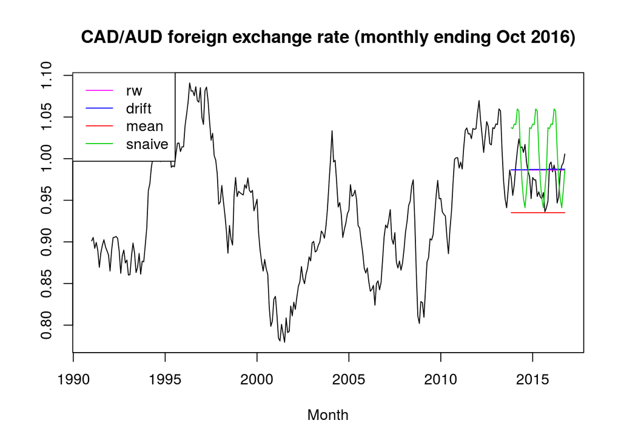

```r
trainset = window(ts_forex, end = c(2013,10)) # produce forecasts up to two years
lambda = BoxCox.lambda(trainset)
forexfit1 = rwf(trainset, h = 36, drift = FALSE, lambda = lambda) # random walk with no drift
forexfit2 = rwf(trainset, h = 36, drift = TRUE, lambda = lambda) # random walk with drift
forexfit3 = meanf(trainset, h = 36, lambda = lambda) # sample average
forexfit4 = snaive(trainset, h = 36,lambda = lambda) # season naive
# ETS = forecast(ets(trainset, lambda = lambda), h = 36)
testset = window(ts_forex, start = c(2013,11))
### shown in graph ###
plot(ts_forex, main="CAD/AUD foreign exchange rate (monthly ending Oct 2016)", ylab="",xlab="Month")
lines(forexfit1$mean,col=6)
lines(forexfit2$mean,col=4)
lines(forexfit3$mean,col=2)
lines(forexfit4$mean,col=3)
legend("topleft",lty=1,col=c(6,4,2,3), legend=c("rw","drift","mean","snaive"))
```

```r
accuracy(forexfit1$mean, testset)
```

```
##                    ME      RMSE        MAE        MPE     MAPE      ACF1
## Test set -0.007344722 0.0245596 0.02046417 -0.8079625 2.107242 0.7406058
##          Theil's U
## Test set  1.504688
```

```r
accuracy(forexfit2$mean, testset)
```

```
##                    ME       RMSE        MAE       MPE     MAPE      ACF1
## Test set -0.007972256 0.02482105 0.02063848 -0.872262 2.126201 0.7426308
##          Theil's U
## Test set  1.521479
```

```r
accuracy(forexfit3$mean, testset)
```

```
##                  ME       RMSE        MAE      MPE     MAPE      ACF1
## Test set 0.04387567 0.04974237 0.04387567 4.426811 4.426811 0.7406058
##          Theil's U
## Test set   2.95499
```

```r
accuracy(forexfit4$mean, testset)
```

```
##                   ME      RMSE        MAE       MPE     MAPE      ACF1
## Test set -0.02916556 0.0553851 0.04916167 -3.035914 5.033664 0.7975875
##          Theil's U
## Test set  3.324907
```

- The residuals are uncorrelated. If there are correlations between residuals, then there is information left in the residuals which should be used in computing forecasts.
- The residuals have zero mean. If the residuals have a mean other than zero, then the forecasts are biased.
- The residuals have constant variance.
- The residuals are normally distributed.

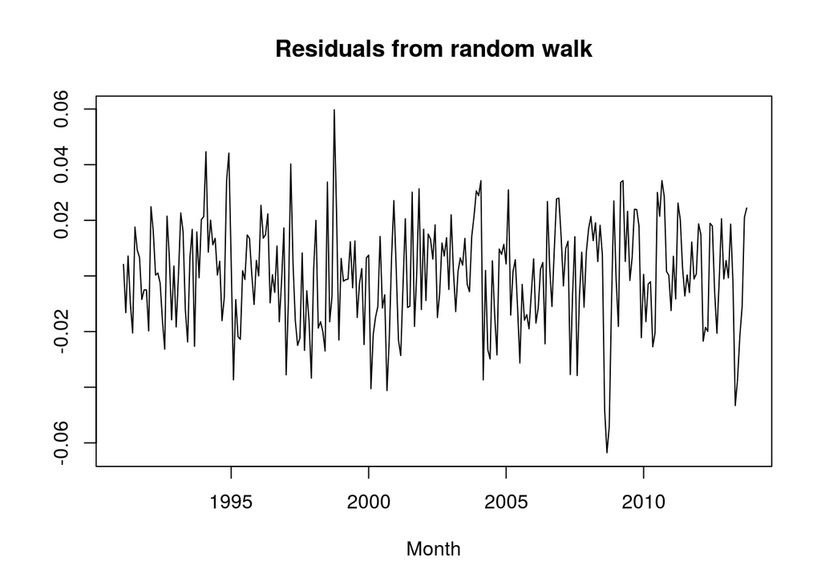

```r
res = residuals(forexfit1)
plot(res, main="Residuals from random walk", ylab="", xlab="Month")
```

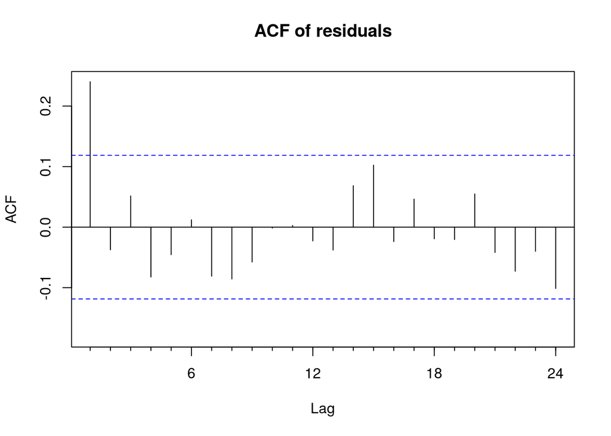

```r
Acf(res, main="ACF of residuals")
```

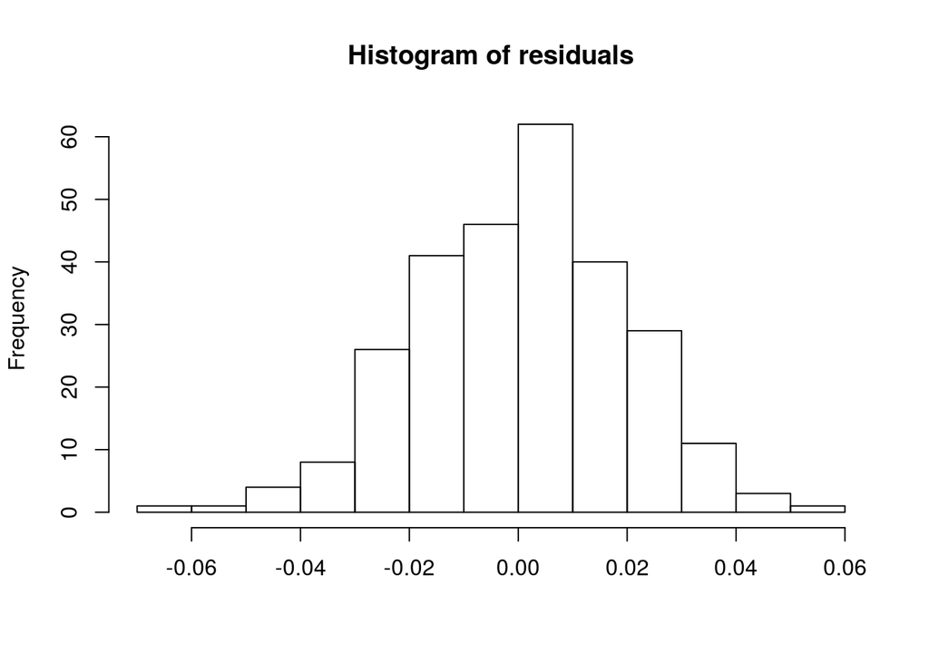

```r
hist(res, nclass="FD", main="Histogram of residuals", xlab="")
```

What we find is that

- mean is close to zero
- correlations appear and still information to explore
- seemlingly stable variance but heavy tail

In fact, we can do formal tests of autocorrelation to confirm.

```r
Box.test(res, lag=20, fitdf=0); Box.test(res,lag=20, fitdf=0, type="Lj")
```

```
##
##  Box-Pierce test
##
## data:  res
## X-squared = 30.467, df = 20, p-value = 0.06263
```

```
##
##  Box-Ljung test
##
## data:  res
## X-squared = 31.331, df = 20, p-value = 0.05096
```

## Extend Naive Benchmarks to ARIMA Models

We select automatcally the proper arima model using **auto.arima()** in “forecast” R package by Rob Hyndman. The exact [Hyndman-Khandakar algorithm](https://www.otexts.org/fpp/8/7) for automatic ARIMA modelling is

1. The number of differences dd is determined using repeated KPSS tests.
2. The values of p and q are then chosen by minimizing the AICs after differencing the data dd times. Rather than considering every possible combination of p and q, the algorithm uses a stepwise search to traverse the model space.
- 2(a) The best model (with smallest AIC) is selected from the following four:

ARIMA(2,d,2), ARIMA(0,d,0), ARIMA(1,d,0), ARIMA(0,d,1).

If $d=0$ then the constant is included; if $d \geq 1$ then the constant is set to zero. This is called the “current model”.

- 2(b) Variations on the current model are considered:

vary p and/or q from the current model by plus/minus $1$; include/exclude the constant from the current model. The best model considered so far (either the current model, or one of these variations) becomes the new current model.

- 3(c) Repeat Step 2(b) until no lower AICs can be found.

```r
### we will go beyond random walk with ARIMA model to explore ###
forexfit = auto.arima(trainset, parallel = TRUE, stepwise = FALSE, seasonal = FALSE, lambda = lambda)
forex_arima = forecast(forexfit, h = 36)
print(forexfit)
```

```
## Series: trainset
## ARIMA(3,1,2)
## Box Cox transformation: lambda= 0.8673674
##
## Coefficients:
##           ar1      ar2     ar3     ma1     ma2
##       -1.3939  -0.5399  0.1671  1.6950  0.9130
## s.e.   0.0810   0.1009  0.0701  0.0547  0.0511
##
## sigma^2 estimated as 0.0003336:  log likelihood=707.62
## AIC=-1403.24   AICc=-1402.93   BIC=-1381.59
```

```r
accuracy(forex_arima$mean, testset)
```

```
##                   ME       RMSE        MAE       MPE     MAPE      ACF1
## Test set -0.01462098 0.02764975 0.02241634 -1.551669 2.320503 0.7340241
##          Theil's U
## Test set  1.700843
```

We can see that the best ARIMA model selected based on [Akaike information criterion](https://en.wikipedia.org/wiki/Akaike_information_criterion) is ARIMA(3,1,2). We will now examine the residuals.

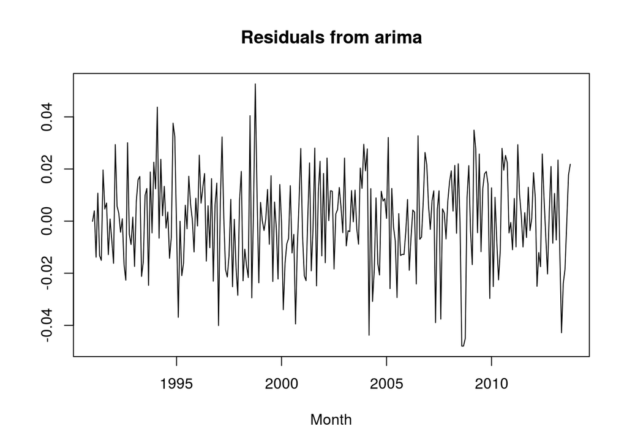

```r
res = residuals(forexfit)
plot(res, main="Residuals from arima", ylab="", xlab="Month")
```

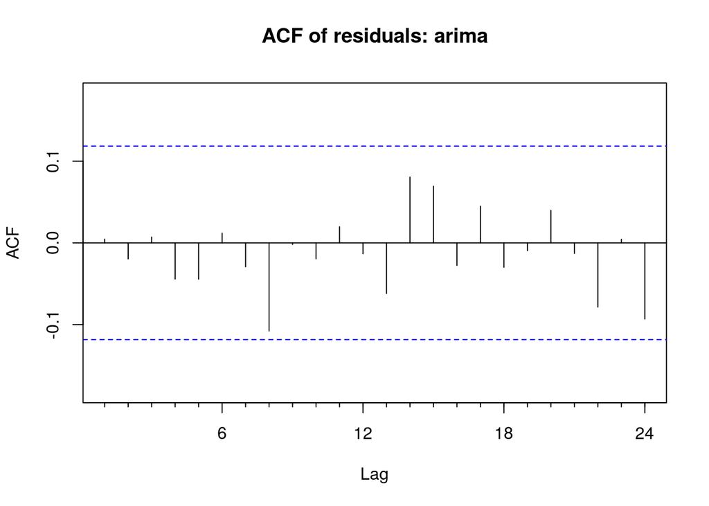

```r
Acf(res, main="ACF of residuals: arima")
```

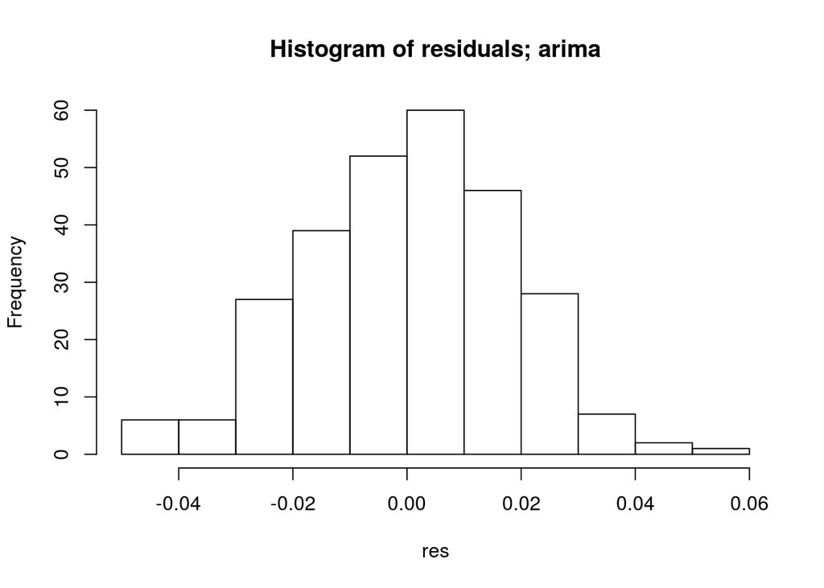

```r
hist(res, nclass="FD", main="Histogram of residuals; arima")
```

```r
Box.test(res, lag=20, fitdf=0); Box.test(res,lag=20, fitdf=0, type="Lj")
```

```
##
##  Box-Pierce test
##
## data:  res
## X-squared = 10.537, df = 20, p-value = 0.9574
```

```
##
##  Box-Ljung test
##
## data:  res
## X-squared = 11.077, df = 20, p-value = 0.9442
```

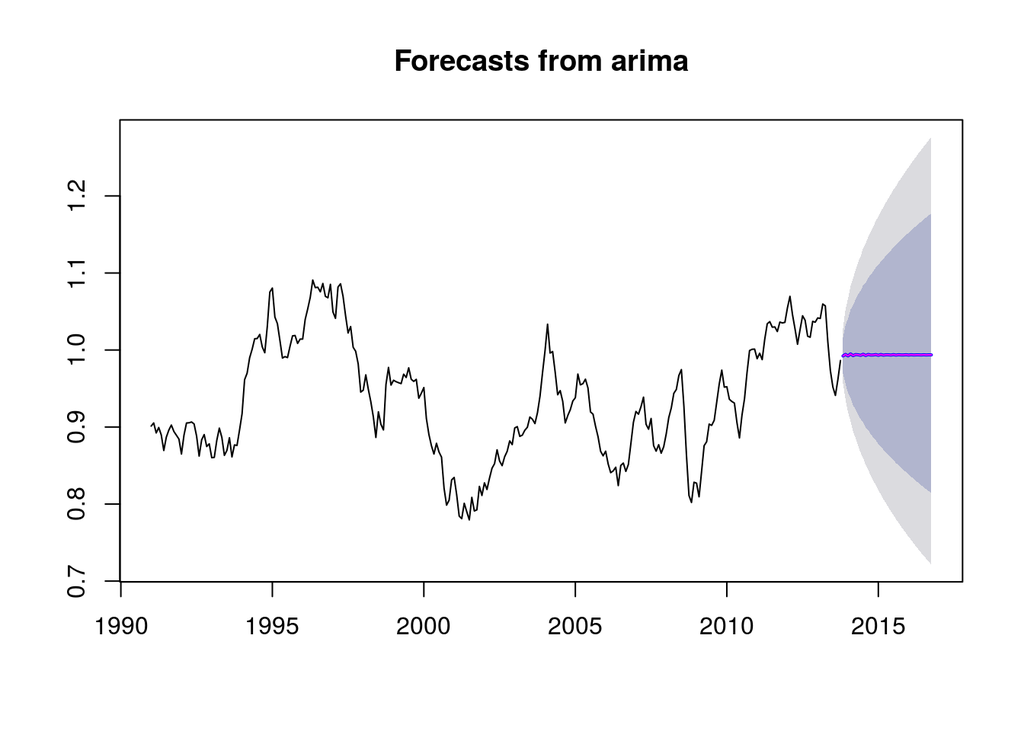

```r
plot(forex_arima, main="Forecasts from arima")
lines(forex_arima$mean,col=6)
```

We have almost completely explored the predictive information about the linear structure of the time series itself. Next, we will look at if external predictors can improve the forecast. Due to the time constrants, I have included the monthly commodity price index from the world bank and some macroeconomic variables for Australia. I have attempted to use the google trend for the key phrase “cad aud” as an indicator accouting for some human behavior, but it does not work.

## Bayesian VAR

We first run a big Bayesian vector autoregressive (VAR) model to see if the predictors can add values. We include $4$ lags for all the predictors since the arima model suggests $3$ lags.

```r
setwd("/home/shenzhou/Dropbox/ANZ_SMALL_PROJECT")
predset = read.csv("./data/predictors3.csv", stringsAsFactors = FALSE)
predset = predset[,-c(1,3,4,5)]
# sapply(predset, mode)
predset = lapply(predset, as.numeric)
predset = as.data.frame(predset)
train_ = predset[1:274,]
# testset = predset[-(1:273),1]
# summary(predset)
# print(sum(colSums(is.na(predset))))

### check and impute missing values with predictive mean match ###
# md.pattern(predset)
# mice_plot = aggr(train_, col=c('navyblue','yellow'), bars = FALSE,
#                   numbers=TRUE, sortVars=TRUE, prop = FALSE,
#                   labels=names(train_), cex.axis=.7,
#                   gap=1, ylab=c("Missing data","Pattern"))
# tempData = mice(train_, m=5, maxit=50, meth='pmm', seed=500)
# # summary(tempData)
# impset = complete(tempData,1)
# print(sum(rowSums(is.na(impset))))
# ### test stationarity ###
# impset[,-c(1,2)] = 100 * log(impset[,-c(1,2)])
# differencing = sapply(impset, ndiffs)
train_[,-c(1,2)] = 100 * log(train_[,-c(1,2)])
differencing = sapply(train_, ndiffs)
# useset = impset[2:nrow(impset),] - impset[1:(nrow(impset)-1),]
useset = train_[2:nrow(train_),] - train_[1:(nrow(train_)-1),]
### estimate Bayesian big VARs ###
# source("codes\\bvar.r")
source("./codes/bvar.r")
# computing fit for the grid of pi's
lag = 4; hori = 36
fit_arima = sqrt(var(ar(useset[,1], aic = FALSE, order.max = lag)$resid, na.rm = TRUE))
fit_rw = sqrt(var(rwf(useset[,1],drift = TRUE)$residuals, na.rm = TRUE))
GRID = c(seq(0, 5, by = 0.025), seq(500, 1000, by = 1))
GRIDsearch = GRID*sqrt(ncol(useset)*lag)
#KK = 0
KK = 0.1
dis = 100; beta_bvar = NULL; tau_bvar = NULL; mu_bvar = NULL; fit_bvar = NULL
for (m in 1:length(GRIDsearch)){
  pi = GRIDsearch[m]    # The overall tightness prior
  mu = pi*KK              # Set the prior on the sum of the coefficients
  # Estimate the Bayesian VAR to get the fit corresponding to the prior pi
  est_bvar = bvarLitt(useset, lag, pi, mu)
  dis_temp = abs(mean(est_bvar$fit) - fit_arima/fit_rw)
  if (dis_temp < dis){ dis = dis_temp; fit_bvar = mean(est_bvar$fit); beta_bvar = est_bvar$beta; tau_bvar = pi; mu_bvar = mu}
  # print("pi");print(pi);print("dis");print(dis) }
}
pred_bvar = NULL; BX_bvar = as.matrix(useset); ft_bvar = NULL
for (h in 1:hori){
  BX_bvar = rbind(BX_bvar, pred_bvar)
  Z = NULL
  for (j in 0:(lag - 1)){ Z = cbind(Z, matrix(BX_bvar[dim(BX_bvar)[1] - j,],nrow = 1))}
  Z = cbind(Z, 1)
  pred_bvar = Z %*% beta_bvar
  ft_bvar = rbind(ft_bvar, pred_bvar)
}
### back transformation ###
forex_bvar = matrix(0,hori,1)
forex_bvar[1] = train_$CAD.AUD[274] + ft_bvar[1,1]
for (i in 2:hori){
forex_bvar[i] = forex_bvar[i-1] + ft_bvar[i,1]
}
forex_bvar = ts(forex_bvar, frequency = 12, start = c(2013,11), end = c(2016,10))
accuracy(forex_bvar, testset)
```

```
##                    ME       RMSE        MAE        MPE     MAPE      ACF1
## Test set -0.007344821 0.02455963 0.02046419 -0.8079727 2.107245 0.7406058
##          Theil's U
## Test set   1.50469
```

The accuracy measures of Bayesian VAR are smaller than ARIMA(3,1,2) which means that the predictors added are useful but not that strong somehow as one may notice.

## Feature Engineering using Least Angle Regression

Normally, it is only worth getting into this part if the Big Bayesian VAR works. Otherwise, go back and find some useful predictors! The biggest advantage of using LARS is that it ranks predictors. In my toy case where I have some weak predictors, so I will still proceed to talk about what the plan is:) I have managed to finish this, since this part is usually the biggest part in machine learning. Ideally, you will come out with several sets of new features containing great predive powers. Then, you will train different models in both linear and nonlinear ways as your final candidates for reinforcement like bagging, boosting or stacking.

```r
library(lars)
######################### least angle regressions ################
### the model is y_t ~ y_t-1 + y_t-2 + y_t-3 + y_t-4 + X_t-1
### where X_t is all the predictors ############################
library(lars)
Y = as.matrix(useset[5:273,1]) # response
X = as.matrix(useset[4:272,-1]) # predictors X_t-1
for (j in lag:1){
  X = cbind(useset[(5-j):(273-j),1], X)
}
es_lars = lars(X, Y, type = "lar", trace = TRUE, use.Gram = FALSE)
```

```
## LAR sequence
## LARS Step 1 :     Variable 33    added
## LARS Step 2 :     Variable 34    added
## LARS Step 3 :     Variable 32    added
## LARS Step 4 :     Variable 36    added
## LARS Step 5 :     Variable 4     added
## LARS Step 6 :     Variable 11    added
## LARS Step 7 :     Variable 30    added
## LARS Step 8 :     Variable 37    added
## LARS Step 9 :     Variable 25    added
## LARS Step 10 :    Variable 3     added
## LARS Step 11 :    Variable 2     added
## LARS Step 12 :    Variable 15    added
## LARS Step 13 :    Variable 35    added
## LARS Step 14 :    Variable 18    added
## LARS Step 15 :    Variable 22    added
## LARS Step 16 :    Variable 10    added
## LARS Step 17 :    Variable 20    added
## LARS Step 18 :    Variable 24    added
## LARS Step 19 :    Variable 14    added
## LARS Step 20 :    Variable 23    added
## LARS Step 21 :    Variable 6     added
## LARS Step 22 :    Variable 28    added
## LARS Step 23 :    Variable 1     added
## LARS Step 24 :    Variable 8     added
## LARS Step 25 :    Variable 9     added
## LARS Step 26 :    Variable 12    added
## LARS Step 27 :    Variable 16    added
## LARS Step 28 :    Variable 5     added
## LARS Step 29 :    Variable 19    added
## LARS Step 30 :    Variable 21    added
## LARS Step 31 :    Variable 13    added
## LARS Step 32 :    Variable 31    added
## LARS Step 33 :    Variable 17    added
## LARS Step 34 :    Variable 29    added
## LARS Step 35 :    Variable 26    added
## LARS Step 36 :    Variable 7     added
## LARS Step 37 :    Variable 27    added
## Computing residuals, RSS etc .....
```

```r
cv_lars = cv.lars(X, Y, plot.it = FALSE, type = "lar", use.Gram = FALSE)
# Use the "+1SE rule" to find best model:
# Take the min CV and add its SE ("limit")
# Find smallest model that has its own CV within this limit (at "scv")
# limit = min(cv_lars$cv) + cv_lars$cv.error[which.min(cv_lars$cv)]
# scv = cv_lars$index[min(which(cv_lars$cv < limit))]
scv = cv_lars$index[which.min(cv_lars$cv)]
# Print out coefficients at optimal s.
coef(es_lars, s = scv, mode = "step")
```

```
##
##               0.0000000000               0.0000000000
##
##               0.0000000000               0.0000000000
##                     Energy                 Non.energy
##               0.0000000000               0.0000000000
##                Agriculture                  Beverages
##               0.0000000000               0.0000000000
##                       Food               Oils...Meals
##               0.0000000000               0.0000000000
##                     Grains                 Other.Food
##               0.0000000000               0.0000000000
##              Raw.Materials                     Timber
##               0.0000000000               0.0000000000
##             Other.Raw.Mat.                Fertilizers
##               0.0000000000               0.0000000000
##         Metals....Minerals Base.Metals..ex..iron.ore.
##               0.0000000000               0.0000000000
##            Precious.Metals               Emp_TotalPer
##               0.0000000000               0.0000000000
##              Hstarts_Total                Hstarts_PDA
##               0.0000000000               0.0000000000
##       Credit_Owner_Housing    Credit_Investor_Housing
##               0.0000000000               0.0000000000
##                   CashRate                        GB5
##               0.0000000000               0.0000000000
##                       GB10                        GBI
##               0.0000000000               0.0000000000
##                     NSWTB3                     NSWTB5
##               0.0000000000               0.0000000000
##                    NSWTB10                    AUD.USD
##               0.0000000000               0.0001447413
##                  AUD_Index                    AUD.CNY
##               0.0012085987               0.0004600705
##                    AUD.JPY                    AUD.GBP
##               0.0000000000               0.0003118407
##            S.P.ASX.AllOrds
##               0.0000000000
```

```r
### predict with lars GLAR ###
LY = as.matrix(useset[5:273,-1]) # response
for (j in lag:1){
  LY = cbind(useset[(5-j+1):(273-j+1),1], LY)
}
es_lars = list(); scv = list()
set.seed(12345)
for (i in 1:ncol(X)) {
  es_lars[[i]] = lars(X, LY[,i], type = "lar", trace = FALSE, use.Gram = FALSE)
  cv_lars = cv.lars(X, LY[,i], plot.it = FALSE, type = "lar", use.Gram = FALSE)
  scv[[i]] = cv_lars$index[which.min(cv_lars$cv)]
}
pred_lars = NULL; ft_lars = NULL
for (h in 1:hori){
  LY = rbind(LY, pred_lars)
  temp = matrix(0,1,ncol(X))
  for (i in 1:ncol(X)){
  Z = matrix(LY[nrow(LY),],nrow = 1)
  temp[i] = predict(es_lars[[i]], newx = Z, type = "fit", s = scv[[i]], mode = "step")$fit
  }
  pred_lars = temp
  ft_lars = rbind(ft_lars, pred_lars)
}
### back transformation ###
forex_lars = matrix(0,hori,1)
forex_lars[1] = train_$CAD.AUD[274] + ft_lars[1,1]
for (i in 2:hori){
  forex_lars[i] = forex_lars[i-1] + ft_lars[i,1]
}
forex_lars = ts(forex_lars, frequency = 12, start = c(2013,11), end = c(2016,10))
accuracy(forex_lars, testset)
```

```
##                   ME       RMSE        MAE       MPE     MAPE      ACF1
## Test set -0.01798278 0.03053565 0.02532483 -1.897423 2.620782 0.7727385
##          Theil's U
## Test set  1.882957
```

## Back-propagation Neural Network

Now we expore the nonlinearity in the time series. We will train nerual network models for both the time series and the predictors. We consider the most phenomenon and common nerual models called back-propagation neural network. Back-propagation uses “backward propagation of errors” which is shown to have great power in training artificial neural networks. Some people use this model to forecast exchange rate and achieve good results. Particularly, it calculates the gradient of a loss function with respect to the weights in the network and then the gradient is fed to the optimization method which in turn uses it to update the weights. Some brief explaination can be found in [wikipedia](https://en.wikipedia.org/wiki/Backpropagation). The idea of applying neural model is not because it sounds awesome. I have read a few artificial intelligence application papers which find Back-propagation Neural Network is really good at picking up nonlinearity of the exchange rate series. Since a good forecast model cannot be either a linear or nonlieanr model alone. We use neural model as a compensation for my big linear models.

```r
library(neuralnet)
set.seed(123) # make the outputs reproducible
# datain = read.csv("data\\predictors2.csv", stringsAsFactors = FALSE)
# datain = read.csv("./data/predictors2.csv", stringsAsFactors = FALSE)
# datain = datain[-nrow(datain),-c(1,3,4,5)]
# n = names(datain); datain = as.matrix(datain)
n = names(predset)
xyvars = NULL
for (j in lag:1){
  # xyvars = cbind(datain[(5-j):(273-j),], xyvars)
  xyvars = cbind(as.matrix(predset[(5-j):(274-j),]), xyvars)
}
xyvars = as.data.frame(xyvars)
### automatically generate variable names
gen_names = NULL
for (i in 1:lag){
  gen_names = c(gen_names, unlist(lapply(n, function(x){paste0(x,"lag",i)})))
}
names(xyvars) = gen_names
xyvars$cadaud = predset[5:274,1]
maxs = apply(xyvars, 2, max); mins = apply(xyvars, 2, min) # scale the data for better fitting performance
# train_ = as.data.frame(scale(xyvars, center = mins, scale = maxs - mins))
train_ = as.data.frame(xyvars)
# f = as.formula(paste("cadaud ~", paste(gen_names, collapse = " + ")))
f = as.formula(paste("cadaud ~", paste(c("CAD.AUDlag1", "CAD.AUDlag2", "CAD.AUDlag3", "CAD.AUDlag4"), collapse = " + ")))
nn = neuralnet(f, data = train_, hidden = c(2), linear.output = TRUE)
ft_nn = NULL; pred_nn = NULL; Z = train_[,"cadaud"]
for (h in 1:hori){
  Z = as.matrix(c(Z, pred_nn))
  newz = lapply(Z[(length(Z)-lag +1):length(Z)], function(x){x})
  # names(newz) = c("CAD.AUDlag1", "CAD.AUDlag2", "CAD.AUDlag3", "CAD.AUDlag4")
  newz = data.frame(newz)
  pred_nn = compute(nn, newz)$net.result; ft_nn = rbind(ft_nn, pred_nn)
}
# forex_nn = ft_nn*(maxs["cadaud"]-mins["cadaud"])+mins["cadaud"] # back transformation
# forex_nn = ft_nn
forex_nn= ts(ft_nn, frequency = 12, start = c(2013,11), end = c(2016,10))
# plot(nn)
accuracy(forex_nn, testset)
```

```
##                      ME         RMSE           MAE         MPE        MAPE
## Test set 0.008808424885 0.0272168263 0.02281277765 0.839809013 2.315541527
##                 ACF1   Theil's U
## Test set 0.726371742 1.600198175
```

## Forecast Combinations

Multiple models must be combined properly to deliver high quality forecasts.

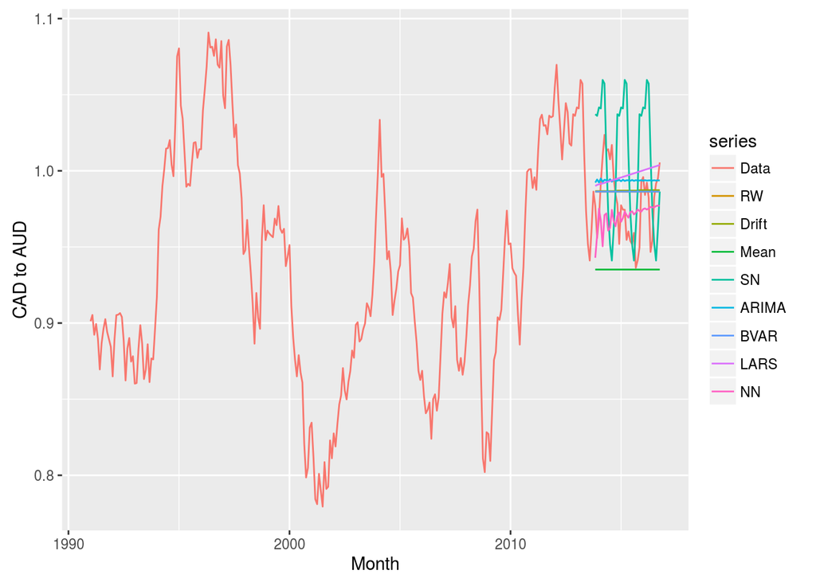

```r
library(opera)
library(ggplot2)
# trainset <- window(ts_forex, end = c(2013,9))
# testset <- window(ts_forex, start = c(2013,10))
h <- length(testset)
X <- cbind(RW=forexfit1$mean, Drift=forexfit2$mean, Mean=forexfit3$mean,
           SN =forexfit4$mean, ARIMA=forex_arima$mean, BVAR=forex_bvar, LARS=forex_lars, NN =forex_nn)
df <- cbind(ts_forex, X)
colnames(df) <- c("Data","RW","Drift","Mean","SN","ARIMA","BVAR","LARS","NN")
autoplot(df) +
  xlab("Month") + ylab(expression("CAD to AUD"))
```

```r
FS <- mixture(model = "FS", loss.type = "square")
weights <- predict(FS, X, testset, type='weights')
head(weights)
```

```
##                X1            X2            X3            X4            X5
## [1,] 0.1250000000 0.12500000000 0.12500000000 0.12500000000 0.12500000000
## [2,] 0.1249945457 0.12499414289 0.12506032932 0.12492931061 0.12498695775
## [3,] 0.1248198680 0.12479894787 0.12828249213 0.12153546984 0.12431289062
## [4,] 0.1220885244 0.12185318639 0.16729088813 0.08888771438 0.11686867265
## [5,] 0.1211825132 0.12097093757 0.16480605941 0.09409013496 0.11702084023
## [6,] 0.0792741774 0.07975531297 0.03659951022 0.49078425773 0.09177200631
##                 X6            X7            X8
## [1,] 0.12500000000 0.12500000000 0.12500000000
## [2,] 0.12499454562 0.12498976382 0.12505040425
## [3,] 0.12481986160 0.12453409856 0.12689637135
## [4,] 0.12208845183 0.11879827882 0.14212428344
## [5,] 0.12118244893 0.11844873144 0.14229833432
## [6,] 0.07927433321 0.08919879386 0.05334160831
```

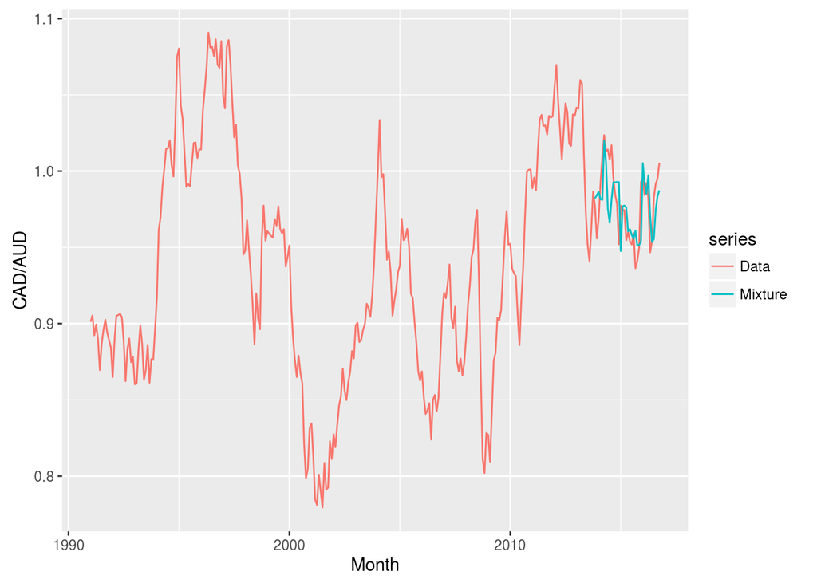

```r
forex_combo  <- ts(predict(FS, X, testset, type='response'), start=c(2013,11), freq=12)
df <- cbind(ts_forex, forex_combo )
colnames(df) <- c("Data","Mixture")
autoplot(df) +
  xlab("Month") + ylab(expression("CAD/AUD"))
```

```r
####### forecast evaluation #######
# accuracy(forexfit1$mean, testset)
# accuracy(forexfit2$mean, testset)
# accuracy(forexfit3$mean, testset)
# accuracy(forexfit4$mean, testset)
# accuracy(ETS$mean, testset)
# accuracy(forex_arima$mean, testset)
# accuracy(forex_bvar, testset)
# accuracy(forex_lars, testset)
# accuracy(forex_nn, testset)
accuracy(forex_combo, testset)
```

```
##                     ME          RMSE           MAE         MPE        MAPE
## Test set 0.00208776091 0.02025450003 0.01584609101 0.179473155 1.613840838
##                  ACF1   Theil's U
## Test set 0.3144709801 1.227687597
```

## Measure the Direction Statistic

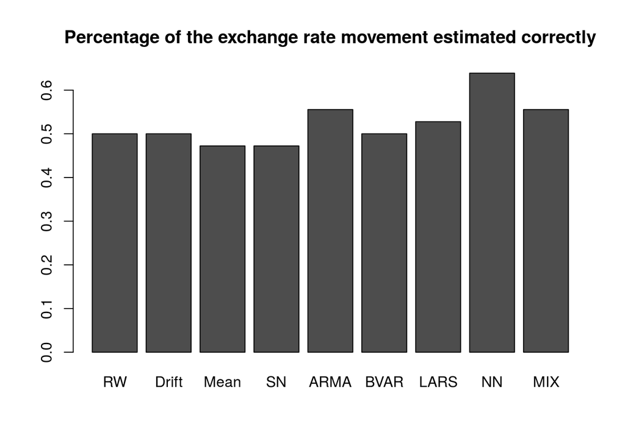

```r
forex_all = list(forexfit1$mean,forexfit2$mean,forexfit3$mean,
                 forexfit4$mean, forex_arima$mean,forex_bvar,forex_lars,forex_nn,forex_combo)
test_ = window(ts_forex, start = c(2013,10), end = c(2016,10)) # produce forecasts up to two years
ds = sapply(forex_all, function (t){stat = mean((t-test_[1:36])*(diff(test_)) > 0)})
ds = matrix(ds,nrow = 1)
colnames(ds) = c("RW","Drift","Mean","SN","ARMA","BVAR","LARS","NN","MIX")
barplot(ds, main="Percentage of the exchange rate movement estimated correctly")
```

## Summary

In general, my toy pipeline seems to be able to beat random walk. Moreover, many things can be done to improve the forecast based on former analysis.

1. Stronger predictors might be found and used, for example, economic indicators from China, India and US. These predictors can be helpful for us to extract new features. Then we can implement vairous linear and nonlinear regression models with them to improve the forecast performance.
2. Back-propagation neural network seems to work extremely good for picking up exchange rate movements. I should explore more on this model. For example, I can tune it more properly with cross validation. Also, it is worth trying other neural models.
3. I should use ensemble algorithms such as bagging, boosting and stacking to combine and manage the predictions of multiple models I run. There is high possibility of reducing forecasting bias and variance further.
4. External forecasts can be used and combined into final forecasts. For example, we can use the consesus exchange rate forecasts provided by [Consensus Economics](http://www.consensuseconomics.com/what_are_consensus_forecasts.htm) which is a popular macroeconomic survey firm.

# Great Thanks for Reading!